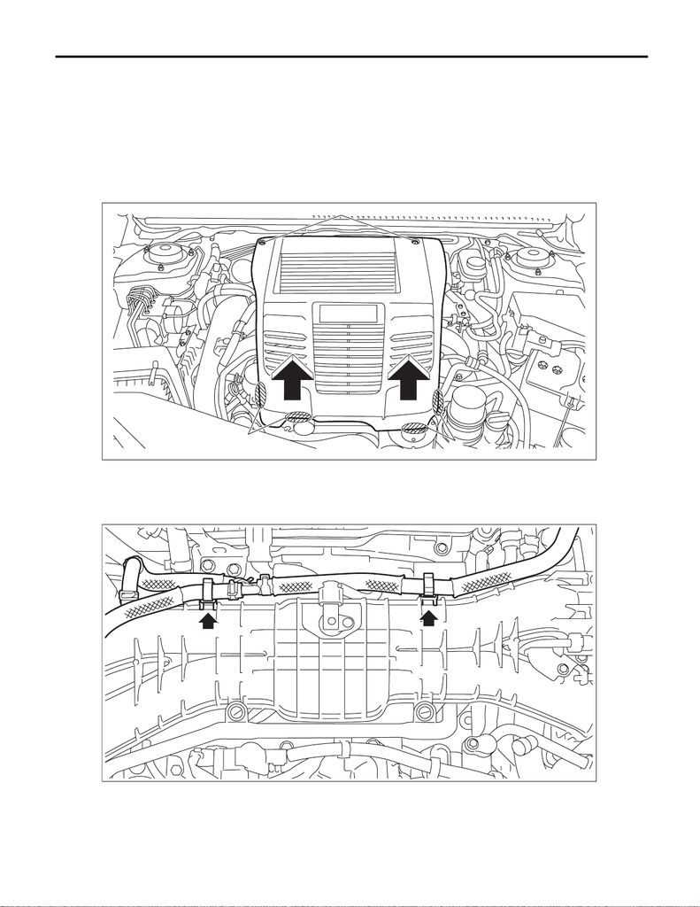

EC(w/o STI)-80

PCV Valve

EMISSION CONTROL (AUX. EMISSION CONTROL DEVICES)

17.PCV Valve

A: REMOVAL

CAUTION:

Do not remove unless the PCV valve is broken.

1) Remove the collector cover.

(1) Remove the clips (A).

(2) Hold the shaded area (B) by hand and carefully pull the RH side (C) upward.

(3) Hold the shaded area (D) by hand and carefully pull the LH side (E) upward.

2) Disconnect the ground terminal from battery sensor. <Ref. to NT-5, BATTERY, NOTE, Note.>

3) Remove the intercooler. <Ref. to IN(w/o STI)-38, REMOVAL, Intercooler.>

4) Remove the clip securing the brake booster vacuum hose to the intake manifold, and move the brake

booster vacuum hose at the locations that do not interfere operation.

EX-03204

(A)

(B)

(C)

(E)

(D)

EC-03455

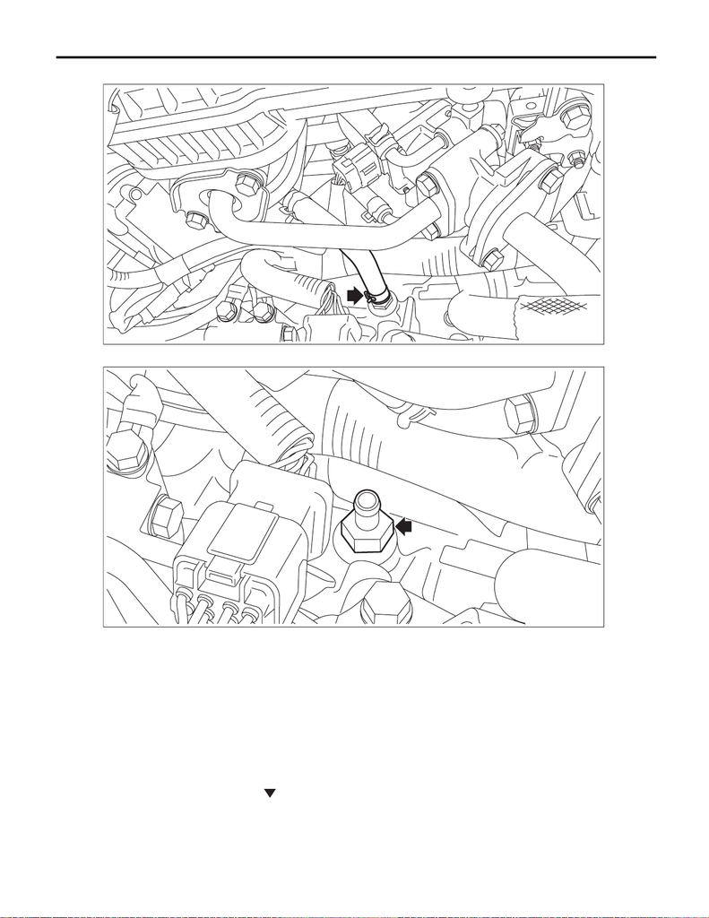

EC(w/o STI)-81

PCV Valve

EMISSION CONTROL (AUX. EMISSION CONTROL DEVICES)

5) Disconnect the PCV hose from the PCV valve.

6) Remove the PCV valve from the cylinder block RH.

B: INSTALLATION

Install in the reverse order of removal.

NOTE:

• Apply liquid gasket to the bolt threads of PCV valve.

Liquid gasket:

THREE BOND 1324 (Part No. 004403042) or equivalent

Tightening torque:

23 N·m (2.3 kgf-m, 17.0 ft-lb)

• When installing the clip which secures the brake booster vacuum hose to the intake manifold, install the

clip to the position of alignment mark of intake manifold.

EC-03211

EC-03152

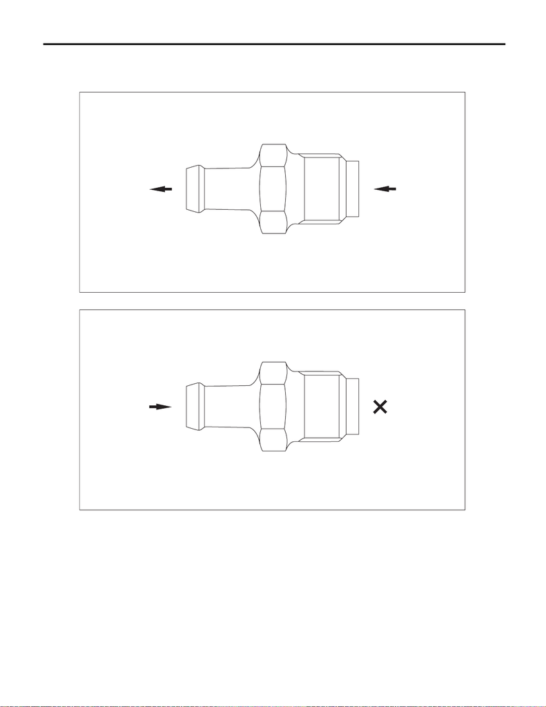

EC(w/o STI)-82

PCV Valve

EMISSION CONTROL (AUX. EMISSION CONTROL DEVICES)

C: INSPECTION

1) Check that the PCV valve has no deformation, cracks or other damages.

2) Check that air is discharged from (B) when air is blown into (A).

EC-02816

(B)

(A)

EC-02817

(A)

(B)

[figure not shown]

INTAKE (INDUCTION)

IN(w/o STI)

Page

1. General Description ...................................................................................2

2. Air Cleaner Element ...................................................................................7

3. Air Cleaner Case ........................................................................................9

4. Air Intake Boot ..........................................................................................17

5. Air Intake Duct ..........................................................................................22

6. Intake Duct ...............................................................................................23

7. Intercooler ................................................................................................38

8. Turbocharger ............................................................................................45

9. Oil Catch Tank .........................................................................................52

10. Scavenge Pump .......................................................................................57

11. Air By-pass Valve .....................................................................................58

12. Resonator Chamber .................................................................................60